# Mid-term Assignment (Due to April. 25th)

## 200903877 황 성 윤

## LG Display Co. Ltd 의 2010년 1월 1일부터 2014년 3월 24일까지의 daily return에 관한 분석.

### 데이터 불러들이기 및 수익률에 관한 그래프 그리기

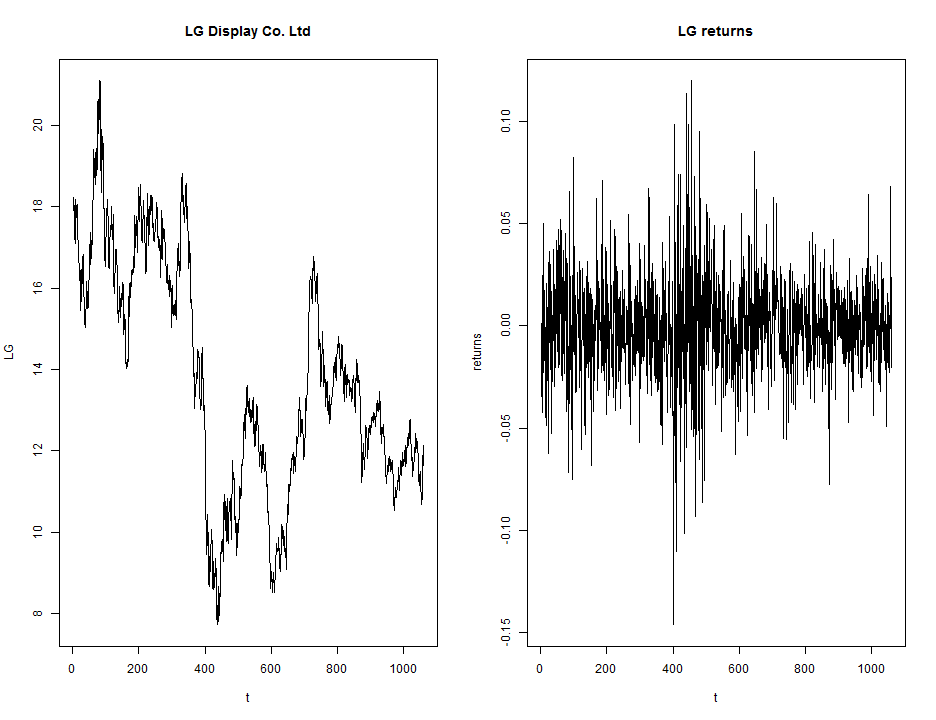

```r
dat.lg <- read.csv("C:/Users/user/Desktop/Sung-yoon.R/Mid-term Exam/LG Display Co., Ltd/lg_daily.csv",
    sep = ",", header = T)
lg <- dat.lg$Close
par(mfrow = c(1, 2))
plot(lg, type = "l", main = "LG Display Co. Ltd", xlab = "t", ylab = "LG")
lg.return <- diff(log(lg))
plot(lg.return, type = "l", main = "LG returns", xlab = "t", ylab = "returns")
```

#### Interpretation

LG Display 주식에 관한 시계열 그래프에서 알 수 있듯이 중반부 시점에서 주가가 크게 하락하였고 전반적으로 최근 5년 동안 주가가 하락하는 추세를 보였음을 알 수 있다. 그리고 주식의 수익률에 관한 그래프를 보면 수익률의 변동성에 대한 지속기간이 전반적으로 길게 나타나고 있는 것으로 판단된다.

### 수익률에 대한 평균, 표준편차, 왜도, 그리고 첨도

```r
z <- scale(lg.return)
skew.lg <- mean(z^3)
kurt.lg <- mean(z^4)
print(c(mean(lg.return), sd(lg.return), skew.lg, kurt.lg))
```

```
## [1] -0.000383  0.026411 -0.001076  5.560847
```

#### Interpretation

평균 : -0.0003830322, 표준편차 : 0.0264105771, 왜도 : -0.0010760994 , 0 –> 음수인 것으로 보아 왼쪽으로 꼬리가 형성되는 것으로 보임, 첨도 : 5.5608465389 > 3 –> 일반적인 정규분포의 첨도인 3보다 크기 때문에 뾰족한 모양의 분포를 형성하고 있는 것으로 보인다.

### 일별 수익률은 정규성을 보이는가?

#### 3. LG Display Co. Ltd

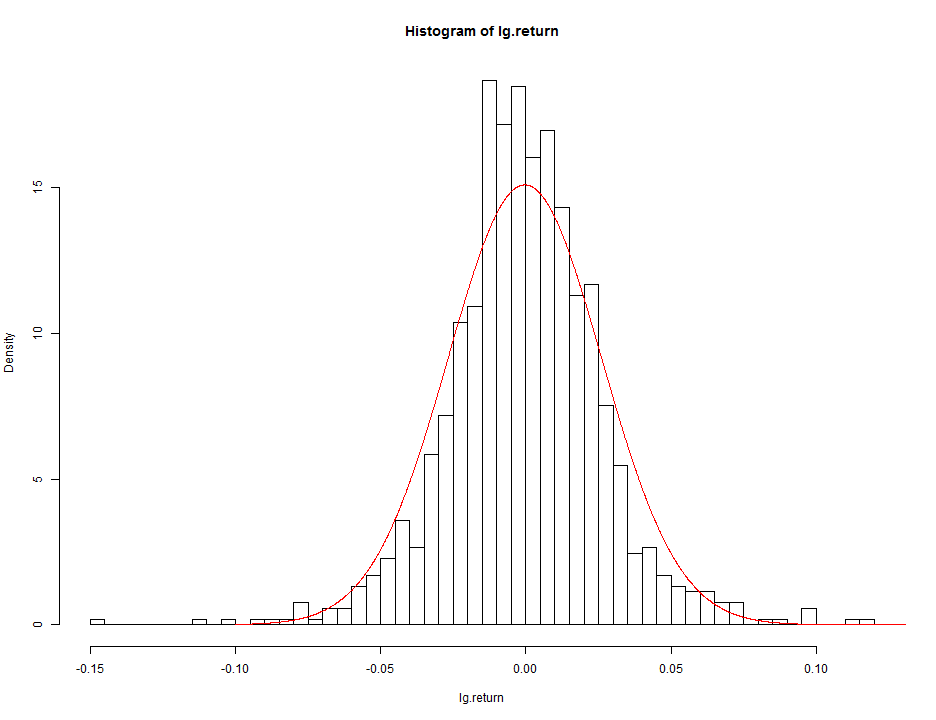

```r
par(mfrow = c(1, 1))
hist(lg.return, prob = T, nclass = 50)
x <- seq(from = -0.1, to = 0.15, by = 1e-04)
lines(x, dnorm(x, mean = mean(lg.return), sd(lg.return)), col = 2)
```

#### Interpretation

히스토그램의 형태가 정규분포와 비교했을 때 뾰족하고 왼쪽에서 꼬리가 형성되고 있으며 더 두꺼움을 알 수 있다. 이 사실을 통해 정규성을 가정하는 것에 있어서는 조심해야 할 것으로 보인다.

### 정규성 검정(Shapiro-Wilk normality test)

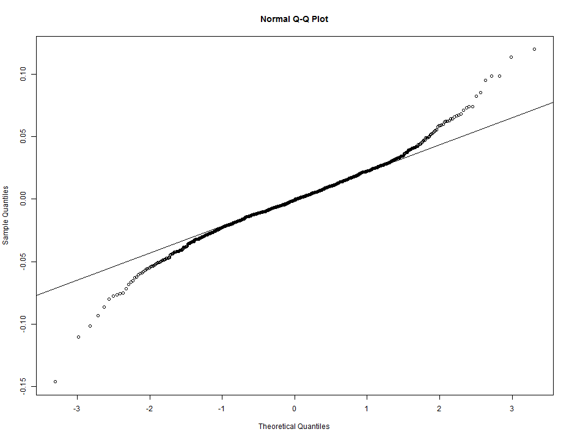

```r
par(mfrow = c(1, 1))
qqnorm(lg.return)
qqline(lg.return)
```

```r
shapiro.test(lg.return)
```

```
##
##  Shapiro-Wilk normality test
##
## data:  lg.return
## W = 0.9735, p-value = 5.379e-13
```

#### Interpretation

Q-Q plot을 통해서 알 수 있듯이 그래프가 직선과 동떨어지는 부분이 양끝에서 발생하고 있음을 알 수 있고, 검정결과 유의확률이 0.05보다 매우 작은 것으로 보아 데이터가 정규분포를 따른다는 H0를 기각한다. 즉, 수익률이 정규성을 띄고 있다고 말할 수 없다.

### 자기상관함수 (Autocorrelation function)

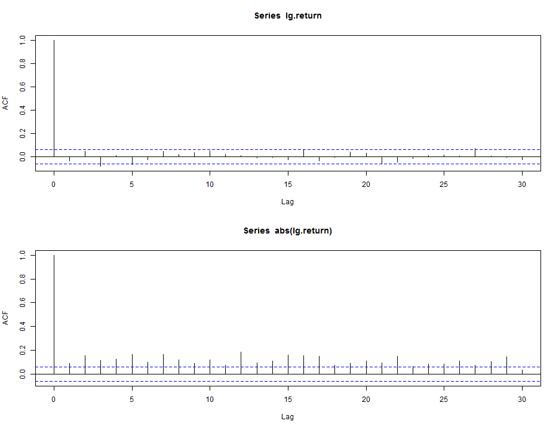

```r
par(mfrow = c(2, 1))
acf(lg.return)
acf(abs(lg.return))
```

#### Interpretation

수익률에 대한 ACF를 보면 대부분 신뢰구간을 벗어나지 않고 있으므로 이전날의 수익률이 현재의 수익률에 미치는 영향력이 크다고 할 수는 없겠다. 그러나 수익률의 절대값에 관한 ACF를 보면 신뢰구간을 뚫고 나오는 경우가 많이 존재하고 있다. 즉, 이전날의 수익률의 변화가 현재의 수익률의 변화에 많은 영향력을 행사하고 있음을 알 수 있다. 그러므로 수익률 자체를 분석하는 것보다 수익률의 변화에 대해서 연구해보는 것이 더 바람직할 것으로 여겨진다.

## Genelarized Hyperbolic Distribution (Normal-Inverse Gaussian Distribution)

### 패키지 fBasics 설치 및 변동성 구하는 함수 생성

```r
install.packages("fBasics")
```

[output not shown]

```r
library(fBasics)
nig.volatility <- function(alpha, beta, delta, mu) {
    gamma <- sqrt(alpha^2 - beta^2)
    ans <- sqrt(delta * alpha^2/gamma^3)
    return(ans)
}
```

```r
par(mfrow = c(1, 2))
nigFit(lg.return)
```

[output not shown]

[output cut: 383 more lines]

[output not shown]

```
##
## Title:
##  Normal Inverse Gaussian Parameter Estimation
##
## Call:
##  .nigFit.mle(x = x, alpha = alpha, beta = beta, delta = delta,
##     mu = mu, scale = scale, doplot = doplot, span = span, trace = trace,
##     title = title, description = description)
##
## Model:
##  Normal Inverse Gaussian Distribution
##
## Estimated Parameter(s):
##      alpha       beta      delta         mu
## 41.6633982  0.8777504  0.0288644 -0.0009913
##
## Description:
##  Mon Apr 21 14:37:39 2014 by user: user
```

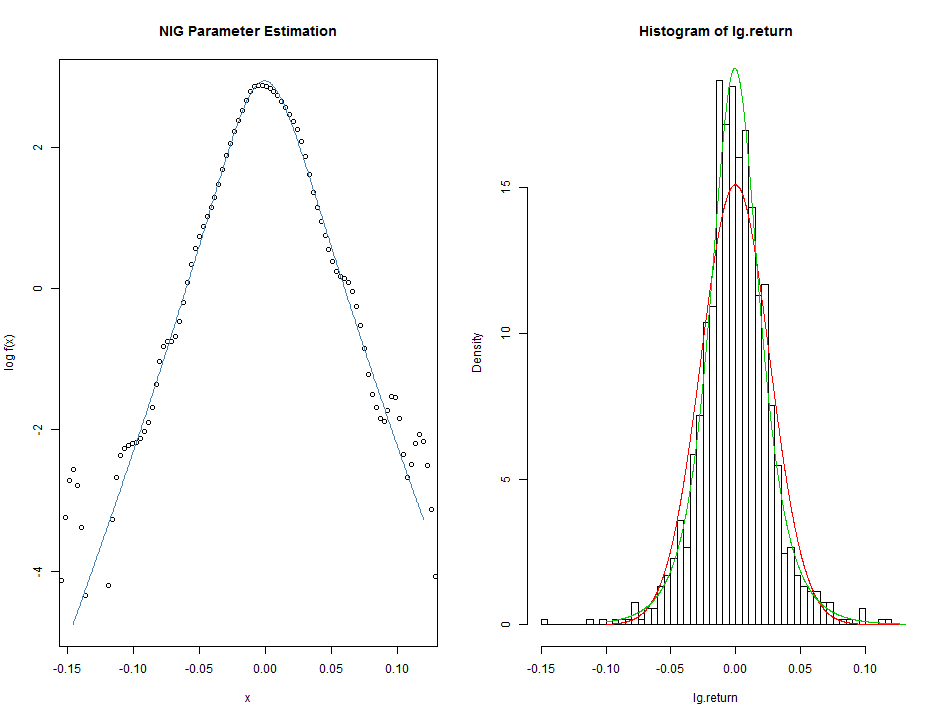

```r
hist(lg.return, prob = T, nclass = 50)
x <- seq(from = -0.1, to = 0.15, by = 1e-04)
lines(x, dnorm(x, mean = mean(lg.return), sd(lg.return)), col = 2)
lines(x, dnig(x, 41.6633981699, 0.8777504231, 0.0288644214, -0.0009912696),
    col = 3)
```

#### Interpretation

수익률의 분포는 정규분포와 거리가 멀다는 것을 확인할 수 있다. 그래프에서 확인할 수 있듯이 Normal-Inverse Gaussian Distribution 에 의한 곡선이 자료의 히스토그램과 더 잘 맞는다는 것을 알 수 있겠다.

### Volatility at Risk

```r
vol.lg <- nig.volatility(41.6633981699, 0.8777504231, 0.0288644214, -0.0009912696)
std.lg <- sd(lg.return)
print(c(vol.lg, std.lg))
```

```
## [1] 0.02633 0.02641
```

#### Interpretation

분포에 의해서 추정된 변동성(volatility)(표준편차)의 값이 실제 자료에 의해서 얻어진 값과 매우 비슷하다.

### Value-at Risk

```r
a1 <- qnig(0.05, 41.6633981699, 0.8777504231, 0.0288644214, -0.0009912696)  # 95% VaR
a2 <- qnorm(0.05, mean(lg.return), sd(lg.return))  # 95% VaR
print(c(a1, a2))
```

```
## [1] -0.04222 -0.04382
```

```r
a3 <- qnig(0.005, 41.6633981699, 0.8777504231, 0.0288644214, -0.0009912696)  # 99.5% VaR
a4 <- qnorm(0.005, mean(lg.return), sd(lg.return))  # 99.5% VaR
print(c(a3, a4))
```

```
## [1] -0.08205 -0.06841
```

```r
a5 <- qnig(0.01, 41.6633981699, 0.8777504231, 0.0288644214, -0.0009912696)  # 99% VaR
a6 <- qnorm(0.01, mean(lg.return), sd(lg.return))  # 99% VaR
print(c(a5, a6))
```

```
## [1] -0.06971 -0.06182
```

### Interpretation

일별주식자료에서 나오는 수익률은 정규분포와는 거리가 멀다. 하지만 Normal-Inverse Gaussian Distribution을 가정하면 그래프를 통해 알 수 있듯이 더 fitting이 바람직하게 됨을 확인할 수 있다. 따라서 Normal-Inverse Gaussian Distribution을 이용하여 분석하는 것이 더 현명한 방법이라고 할 수 있으며 Value-at-Risk 에서도 알 수 있듯이 정규분포는 위험을 더 과소평가하는 경향이 있으므로 정규분포임을 가정하여 수익률을 분석할 경우 잘못된 해석결과가 나올 수 있으니 조심해야 하겠다.

### 패키지 tseries 설치

```r
install.packages("tseries")
```

[output not shown]

```r
library(tseries)
```

## Finance time series model

### Conditional Heteroscedastic Model

### S(t) : asset price

### r(t) = log(S(t))-log(S(t-1)) : log-return or return

### r(t) = sigma(t)*e(t) , e(t) ~ WN(0,1) (e : epsilon)

### sigma(t)<sup>2</sup> = Var(r(t) | r(t-1), r(t-2), …)

### = E(r(t)<sup>2</sup> | r(t-1), r(t-2), …)

### GARCH 모형에서 모수를 추정 후 잔차를 이용하여 검진실시.

### (잔차에 대한 acf 그림을 그린다.

### 그리고 Box-Ljung test 실시. H0 : 상관관계 없음.)

### Generalized Autoregressive Conditional Heteroscedastic Model

### (GARCH Model)

### (자기회귀 & 이분산성 (과거의 기록을 조건부로 이용))

### Engle -> Bollerslev

### Volatility 를 모형화하기 위한 model

### ARCH(p) –>

### sigma(t)<sup>2</sup> = alpha(0) + alpha(1)*r(t-1)<sup>2</sup> +

### alpha(2)*r(t-2)<sup>2</sup> + … + alpha(p)*r(t-p)<sup>2</sup> (t=1,2,…,T)

### GARCH(p,q) –>

### sigma(t)<sup>2</sup> = alpha(0) + alpha(1)*r(t-1)<sup>2</sup> +

### alpha(2)*r(t-2)<sup>2</sup> + … + alpha(p)*r(t-p)<sup>2</sup> +

### beta(1)*sigma(t-1)<sup>2</sup> + beta(2)*sigma(t-2)<sup>2</sup> + …

### + beta(q)*sigma(t-q)<sup>2</sup> (t=1,2,…,T)

### 일반적으로 GARCH(1,1) 으로 충분하다고 알려져있음.

### 수익률, 자료에 적합된 GARCH model에 의해 추정된 변동성 및 잔차에 관한 그래프 (여기에서는 GARCH(1,1) 모형을 가정하고 분석할 것임.)

```r
vol.lg <- garch(lg.return)
```

[output not shown]

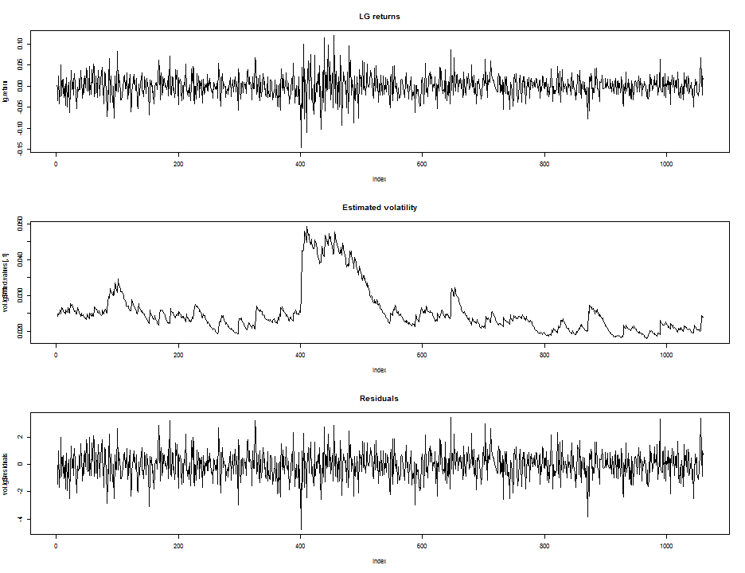

```r
par(mfrow = c(3, 1))
plot(lg.return, type = "l", main = "LG returns")
plot(vol.lg$fitted.values[, 1], type = "l", main = "Estimated volatility")
plot(vol.lg$residuals, type = "l", main = "Residuals")
```

#### Interpretation

수익률의 변동성이 시간에 따라 달라지는 것으로 보아 GARCH model을 적합시켜 분석해볼 필요가 있겠다.

### 적합된 GARCH model에 대한 검진(GARCH(1,1))

```r
summary(vol.lg)
```

```
##
## Call:
## garch(x = lg.return)
##
## Model:
## GARCH(1,1)
##
## Residuals:
##     Min      1Q  Median      3Q     Max
## -4.8080 -0.6238 -0.0305  0.5886  3.4635
##
## Coefficient(s):
##     Estimate  Std. Error  t value Pr(>|t|)
## a0  1.13e-05    4.36e-06     2.59   0.0095 **
## a1  4.38e-02    7.89e-03     5.56  2.7e-08 ***
## b1  9.39e-01    1.27e-02    73.79  < 2e-16 ***
## ---
## Signif. codes:  0 '***' 0.001 '**' 0.01 '*' 0.05 '.' 0.1 ' ' 1
##
## Diagnostic Tests:
##  Jarque Bera Test
##
## data:  Residuals
## X-squared = 59.26, df = 2, p-value = 1.357e-13
##
##
##  Box-Ljung test
##
## data:  Squared.Residuals
## X-squared = 0.1935, df = 1, p-value = 0.66
```

#### Interpretation

Approximation t-test에 의하면 추정된 모수가 모두 유의한 것으로 나타났고 Jarque Bera test 결과 유의확률이 0.05본다 매우 작은 값으로 나타나므로 변동성을 분석할 때 정규분포를 가정하는 것에는 무리가 있다고 할 수 있다. 또한 Box-Ljung test 결과 유의확률이 0.05보다 큰 값으로 나타나고 있으므로 모형이 자료를 잘 적합시키고 있다고 판단할 수 있겠다.

### 잔차의 ACF를 이용한 모형의 검진

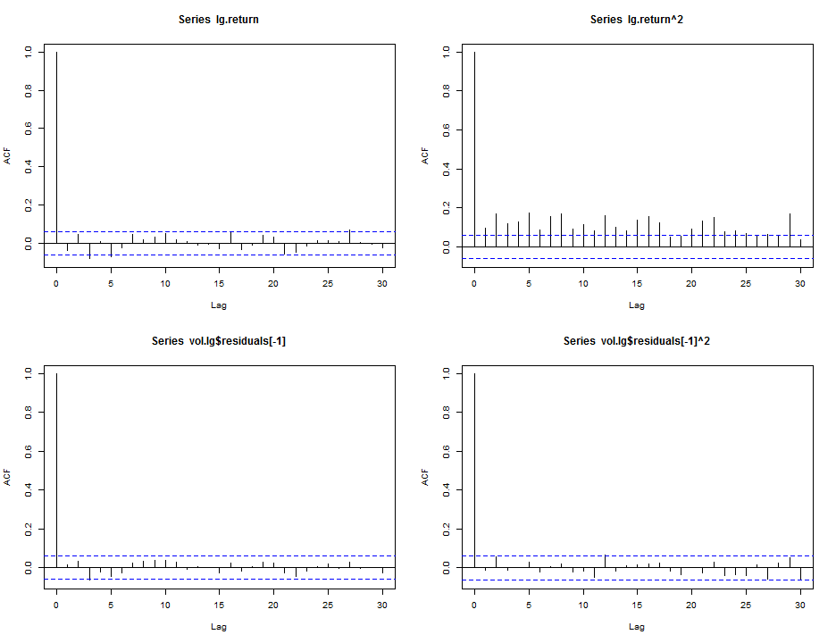

```r
par(mfrow = c(2, 2))
acf(lg.return)
acf(lg.return^2)
acf(vol.lg$residuals[-1])
acf(vol.lg$residuals[-1]^2)
```

#### Interpretation

잔차에 대한 ACF와 잔차를 제곱한 값에 대한 ACF가 대부분 신뢰구간 안에 들어가 있으므로 모형적합이 잘 되었다고 말할 수 있다. 그리고 수익률에 대한 ACF를 통하여 수익률 자체를 분석하는 것 보다는 그것을 제곱하여 얻어진 값들을 분석하는 것이 더 타당하다고 할 수 있겠다.

#### If r ~ N( 0 , sigma<sup>2</sup> ) , it is not true..

#### r(t) = sigma(t)*e(t) , e(t) ~ WN(0,1) (e : epsilon)

#### e(t) is called random shocks..

#### GARCH(1,1) -> sigma(t)<sup>2</sup> = alpha(0) + alpha(1)*r(t-1)<sup>2</sup>

#### + beta(1)*sigma(t-1)<sup>2</sup>

#### Refer to Jarque Bera Test, e(t) is nonnormal~~!!

#### 잔차의 분포를 구할 필요성.

#### 잔차에 관해서 plot을 그리고 정규성 확인

### 잔차 epsilon에 대한 분포 점검

```r
par(mfrow = c(1, 2))
vol.lg <- garch(lg.return)
```

[output not shown]

```r
res.lg <- vol.lg$residuals[-1]
nigFit(res.lg)
```

[output not shown]

[output cut: 329 more lines]

[output not shown]

```
##
## Title:
##  Normal Inverse Gaussian Parameter Estimation
##
## Call:
##  .nigFit.mle(x = x, alpha = alpha, beta = beta, delta = delta,
##     mu = mu, scale = scale, doplot = doplot, span = span, trace = trace,
##     title = title, description = description)
##
## Model:
##  Normal Inverse Gaussian Distribution
##
## Estimated Parameter(s):
##     alpha      beta     delta        mu
##  1.525804 -0.012642  1.530869 -0.009035
##
## Description:
##  Mon Apr 21 14:37:41 2014 by user: user
```

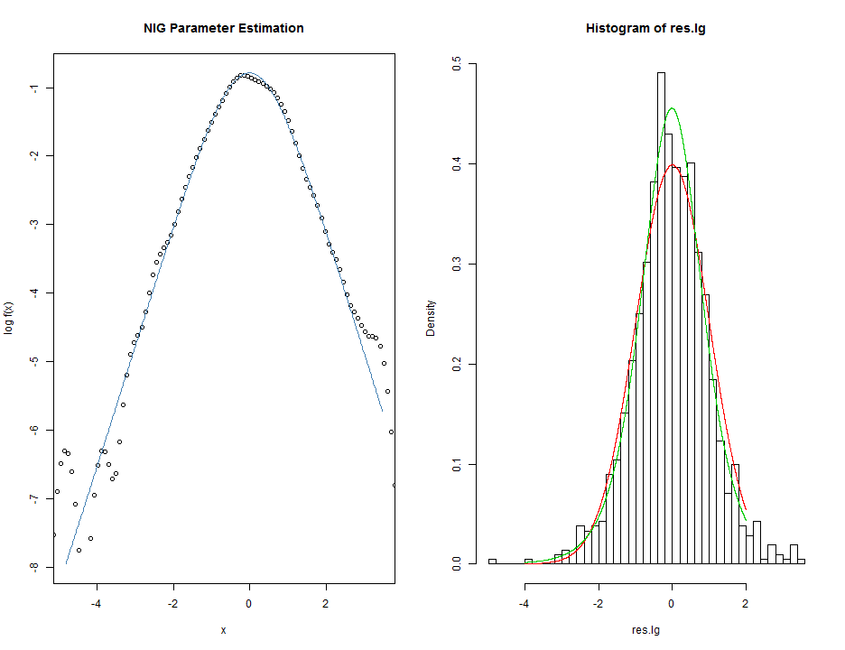

```r
hist(res.lg, prob = T, nclass = 50)
x <- seq(-4, 2, by = 0.001)
lines(x, dnorm(x), col = 2)
lines(x, dnig(x, 1.5258037, -0.01264153, 1.53086941, -0.00903504), col = 3)
```

#### Interpretation

GARCH(1,1) 모형을 통해서 얻어진 잔차의 분포를 정규분포로 가정하기에는 무리가 있음을 알 수 있다. 대신 Normal Inverse Gaussian Distribution을 이용하여 적합시켰을 경우에는 적합도가 상당히 좋아지는 것을 히스토그램과 그래프를 통하여 알 수 있다.

## Time varying VaR (시간에 따라 변하는 Value-at-Risk)

#### P(r(t) <= x ) = 0.01 (Value-at-Risk)

#### P(sigma(t)*e(t) <= sigma(t)*y ) = 0.01 (Find y!!)

#### epsilon(t)의 분포는 고정되어있다고 가정하고 sigma(t)는 시간에 따라 변하고 있다고 가정하게 되면 epsilon(t)의 분포를 통해 얻어지는 VaR의 값에 GARCH 모형을 통해 적합된 변동성(volatility)의 값을 곱하여 시간에 따라 변하는 Value-at-Risk를 얻어낼 수 있다.

### Time varying VaR

[figure not shown]

```r
par(mfrow = c(1, 1))
q.05 <- qnig(0.05, 1.5258037, -0.01264153, 1.53086941, -0.00903504)
q.01 <- qnig(0.01, 1.5258037, -0.01264153, 1.53086941, -0.00903504)
q.005 <- qnig(0.005, 1.5258037, -0.01264153, 1.53086941, -0.00903504)
sigma.t <- vol.lg$fitted.values[-1, 1]
VaR.95 <- sigma.t * q.05
VaR.99 <- sigma.t * q.01
VaR.995 <- sigma.t * q.005
n <- length(lg.return)
plot(lg.return, type = "l", ylim = c(-0.15, 0.15))
lines(2:n, VaR.95, col = 2)
lines(2:n, VaR.99, col = 3)
lines(2:n, VaR.995, col = 4)
legend("topleft", c("95% VaR", "99% VaR", "99.5% VaR"), lty = rep(1, 3), col = c(2,
    3, 4))
```

#### Interpretation

그래프에서 빨간색선은 95% VaR, 녹색선은 99% VaR, 그리고 파란색선은 99.5% VaR를 나타낸다. 이는 수익률에 해당하는 검정색 그래프가 빨간색선 아래쪽으로 1000번 중 50번, 녹색선 아래로 10번, 그리고 파란색선 아래로 5번 정도 내려간다는 것을 의미한다. 실제 위에 있는 그래프를 보면 평균적으로 이러한 형태를 보이고 있다.

### 정확도 확인

```r
q.05 <- qnig(0.05, 1.5258037, -0.01264153, 1.53086941, -0.00903504)
q.01 <- qnig(0.01, 1.5258037, -0.01264153, 1.53086941, -0.00903504)
q.005 <- qnig(0.005, 1.5258037, -0.01264153, 1.53086941, -0.00903504)
sigma.t <- vol.lg$fitted.values[-1, 1]
VaR.N95 <- sigma.t * qnorm(0.05)
VaR.N99 <- sigma.t * qnorm(0.01)
VaR.N995 <- sigma.t * qnorm(0.005)
VaR.95 <- sigma.t * q.05
VaR.99 <- sigma.t * q.01
VaR.995 <- sigma.t * q.005
print(c(abs(0.05 - mean(lg.return[-1] < VaR.N95)), abs(0.05 - mean(lg.return[-1] <
    VaR.95))))
```

```
## [1] 0.00288 0.00288
```

```r
print(c(abs(0.01 - mean(lg.return[-1] < VaR.N99)), abs(0.01 - mean(lg.return[-1] <
    VaR.99))))
```

```
## [1] 0.007941 0.002446
```

```r
print(c(abs(0.005 - mean(lg.return[-1] < VaR.N995)), abs(0.005 - mean(lg.return[-1] <
    VaR.995))))
```

```
## [1] 0.002554 0.001223
```

#### Interpretation

위에 있는 내용은 분포를 가정해서 얻어진 위험성과 실제 우리가 얻고자 기대하는 위험성 간의 차이를 비교해본 것이다. 값이 더 클수록 위험성을 부정확하게 측정했다고 판단하면 된다. 결과를 보면 전반적으로 정규분포를 가정했을 때보다 Normal Inverse Gaussian Distribution을 가정했을 경우에 위험성이 더 정확하게 측정되고 있음을 알 수 있다. 일반적으로 정규분포는 수익률의 위험성을 과소평가하는 경향이 있다는 것도 참고적으로 남겨둔다.

## Backtest VaR (Value-at-Risk를 평가하는 방법)

### N : number of 100*(1-p)% VaR violations

### T : total number of observations

### H0 : N ~ B(T,p) vs H1 : not H0

### LRT statistic = - 2*log{((1-p)<sup>T-N</sup>)*((p)<sup>N</sup>)} + 2*log{((1-N/T)<sup>T-N</sup>)*((N/T)<sup>N</sup>)}

### –>d(Convergence in distribution)

### Chi-square distribution with df=1 under H0

### (LRT statistic = -2*log(L0/L))

### p-value의 값이 유의수준 0.05보다 큰 값을 가지는 경우

### 수익률에 대한 분포의 가정이 올바르게 되었다고 판단.

### 가설검정을 위한 함수 작성

```r
backtest.VaR <- function(N.violations, N.total, p) {
    p.hat <- N.violations/N.total
    LR <- -2 * log((1 - p)^(N.total - N.violations) * p^N.violations) + 2 *
        log((1 - p.hat)^(N.total - N.violations) * p.hat^N.violations)
    p.value <- 1 - pchisq(LR, 1)
    return(list(excess.prob = p.hat, LR = LR, p.value = p.value))
}
```

### NIG Assumption

```r
q.05 <- qnig(0.05, 1.5258037, -0.01264153, 1.53086941, -0.00903504)
q.01 <- qnig(0.01, 1.5258037, -0.01264153, 1.53086941, -0.00903504)
q.005 <- qnig(0.005, 1.5258037, -0.01264153, 1.53086941, -0.00903504)
sigma.t <- vol.lg$fitted.values[-1, 1]
VaR.95 <- sigma.t * q.05
VaR.99 <- sigma.t * q.01
VaR.995 <- sigma.t * q.005
backtest.VaR(sum(lg.return[-1] < VaR.95), length(lg.return[-1]), 0.05)
```

```
## $excess.prob
## [1] 0.05288
##
## $LR
## [1] 0.1817
##
## $p.value
## [1] 0.6699
```

```r
backtest.VaR(sum(lg.return[-1] < VaR.99), length(lg.return[-1]), 0.01)
```

```
## $excess.prob
## [1] 0.007554
##
## $LR
## [1] 0.6989
##
## $p.value
## [1] 0.4032
```

```r
backtest.VaR(sum(lg.return[-1] < VaR.995), length(lg.return[-1]), 0.005)
```

```
## $excess.prob
## [1] 0.003777
##
## $LR
## [1] 0.3478
##
## $p.value
## [1] 0.5553
```

#### Interpretation

95% VaR, 99% VaR, 그리고 99.5% VaR 모두 p-value의 값이 0.05보다 큰 값을 나타내고 있다. 따라서 분포의 가정이 올바르다는 귀무가설을 기각하지 못하게 된다. 그러므로 일별주식자료에서 나온 수익률을 분석할 때 Normal Inverse Gaussian Distribution을 가정하는 것이 타당하다고 말할 수 있겠다.

### Normality Assumption

```r
sigma.t <- vol.lg$fitted.values[-1, 1]
VaR.N95 <- sigma.t * qnorm(0.05)
VaR.N99 <- sigma.t * qnorm(0.01)
VaR.N995 <- sigma.t * qnorm(0.005)
backtest.VaR(sum(lg.return[-1] < VaR.N95), length(lg.return[-1]), 0.05)
```

```
## $excess.prob
## [1] 0.05288
##
## $LR
## [1] 0.1817
##
## $p.value
## [1] 0.6699
```

```r
backtest.VaR(sum(lg.return[-1] < VaR.N99), length(lg.return[-1]), 0.01)
```

```
## $excess.prob
## [1] 0.01794
##
## $LR
## [1] 5.46
##
## $p.value
## [1] 0.01946
```

```r
backtest.VaR(sum(lg.return[-1] < VaR.N995), length(lg.return[-1]), 0.005)
```

```
## $excess.prob
## [1] 0.007554
##
## $LR
## [1] 1.2
##
## $p.value
## [1] 0.2734
```

#### Interpretation

주어진 결과를 보면 p-value의 값이 0.05보다 큰 경우도 있지만 그렇지 않은 경우도 존재한다. 이 말은 수익률에 관해 정규분포를 가정할 경우 문제가 있을 수 있다는 이야기이다. 결국 일별주식자료에서 나온 수익률을 분석할 때 정규분포를 가정하는 것은 잘못된 방법이라고 할 수 있겠다.